# Giới thiệu về mô hình toán học trong dịch tễ học và kiểm soát bệnh truyền nhiễm

Tác giả

Phùng Khánh Lâm, Ong Phúc Thịnh

Công bố

March 2, 2023

## 2 Dịch tễ học bệnh truyền nhiễm

Bệnh truyền nhiễm gây ra do sự lây truyền các tác nhân gây bệnh trong dân số cảm nhiễm, và đặc trưng bởi khả năng lây lan từ người này sang người khác, qua dây chuyền lây.

Diễn tiến theo thời gian của bệnh truyền nhiễm trong một cá thể có thể được mô tả theo diễn tiến lâm sàng hoặc theo khả năng lây nhiễm. Về diễn tiến lâm sàng, bệnh bao gồm các giai đoạn: cảm nhiễm, bệnh bán lâm sàng (sau khi nhiễm bệnh và trước khi có biểu hiện lâm sàng), bệnh lâm sàng, hồi phục/tàn tật/tử vong. Theo khả năng lây nhiễm, bệnh bao gồm giai đoạn tiềm ẩn và giai đoạn lây nhiễm. Hình 1 tóm tắt bệnh sử tự nhiên và dây chuyền lây của bệnh truyền nhiễm.

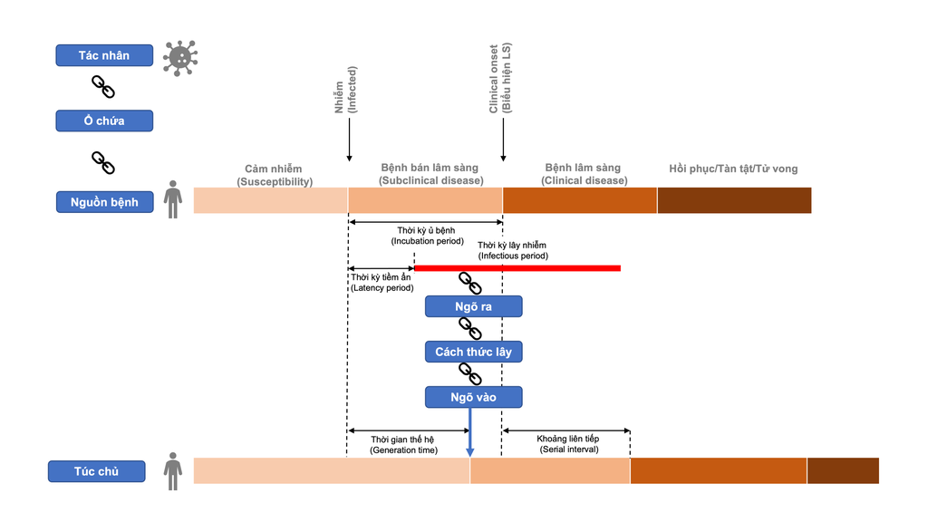

Hình 1: Lịch sử tự nhiên và dây chuyền lây của bệnh truyền nhiễm

Mặc dù bệnh truyền nhiễm có thể do nhiều loại tác nhân gây bệnh khác nhau gây ra (virus, vi khuẩn, ký sinh trùng) và có nhiều cơ chế lây truyền khác nhau (khí dung/giọt bắn, phân miệng, quan hệ tình dục, vật trung gian, …), tuy nhiên kết quả cuối cùng đều giống nhau khi xét ở góc độ cộng đồng

- từ một (một số) người nhiễm ban đầu,
- bệnh được lây truyền tiếp tục cho những người khác,
- tạo ra một chuỗi phản ứng dây chuyền, từ đó tạo thành một vụ dịch

Thông thường, một vụ dịch bệnh truyền nhiễm sẽ trải qua 4 giai đoạn (WHO 2018): khởi phát, lây truyền tại chỗ, lan rộng, và suy giảm. Hình 2 minh hoạ 4 giai đoạn này cùng các nhóm biện pháp đáp ứng tương ứng.

WHO. 2018. *Managing Epidemics: Key Facts about Major Deadly Diseases.*

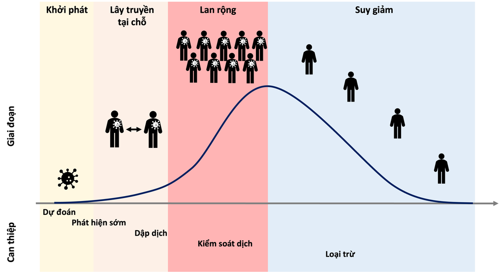

Hình 2: Các giai đoạn của một vụ dịch và biện pháp đáp ứng

Dưới góc độ của người phải đưa ra các quyết định nhằm đáp ứng với vụ dịch, những câu hỏi sau cần phải được trả lời (Cori et al. 2017)

Cori, Anne, Christl A. Donnelly, Ilaria Dorigatti, Neil M. Ferguson, Christophe Fraser, Tini Garske, Thibaut Jombart, et al. 2017. “Key Data for Outbreak Evaluation: Building on the Ebola Experience.” *Philosophical Transactions of the Royal Society B: Biological Sciences* 372 (1721): 20160371. https://doi.org/10.1098/rstb.2016.0371.

1. Liệu vụ dịch có bùng phát hay không?
2. Vụ dịch sẽ có tác động như thế nào đến y tế công cộng? (mức độ nghiêm trọng của vụ dịch)
3. Liệu có thể kiểm soát được vụ dịch hay không?
4. Biện pháp nào là phù hợp để kiểm soát vụ dịch?
5. Liệu biện pháp can thiệp đang được sử dụng có hiệu quả không và chúng ta có thể cải thiện biện pháp này như thế nào?

Để trả lời những câu hỏi này, chúng ta cần ước tính được khả năng lây truyền (transmissibility) của dịch. Khả năng lây truyền của dịch có thể được ước tính thông qua hai chỉ số dịch tễ học (Anderson et al. 2020)

Anderson, Roy, Christl Donnelly, Deirdre Hollingsworth, Matt Keeling, Carolin Vegvari, Rebecca Baggaley, and Rosie Maddren. 2020. “Reproduction Number (R) and Growth Rate (r) of the COVID-19 Epidemic in the UK.”

- Hệ số lây nhiễm (reproductive number, $R$): số lượng ca nhiễm thứ phát từ một ca nhiễm nguyên phát ban đầu.
- Tốc độ tăng trưởng của dịch (epidemic growth rate, $r$): số ca nhiễm tăng lên trong một đơn vị thời gian. Tốc độ tăng trưởng này phụ thuộc vào hai thông số: hệ số lây nhiễm và khoảng thời gian giữa hai thế hệ lây nhiễm.

### 2.1 Hệ số lây nhiễm $R$

Hệ số lây nhiễm (Reproductive number, $R$) là số ca nhiễm trung bình từ một ca nhiễm điển hình ban đầu trong suốt khoảng thời gian lây bệnh của ca nhiễm đó.

Hệ số lây nhiễm cơ bản (Reproductive number, $R_0$) là số ca nhiễm trung bình từ một ca nhiễm điển hình ban đầu trong suốt khoảng thời gian lây bệnh của ca nhiễm đó, **trong dân số hoàn toàn cảm nhiễm với bệnh** (tại thời điểm dịch mới xuất hiện).

### 2.2 Tốc độ tăng trưởng của dịch (epidemic growth rate, $r$)

Thể hiện số ca nhiễm tăng lên trong một đơn vị thời gian.

Tốc độ tăng trưởng này phụ thuộc vào hai thông số: hệ số lây nhiễm (reproductive number) và khoảng thời gian giữa hai thế hệ lây nhiễm (generation time).

$r$ có thể được ước tính theo công thức

$$r = \dfrac{R-1}{Tg}$$

Với $R$ là hệ số lây nhiễm và $T_g$ là khoảng thời gian trung bình giữa hai thế hệ lây nhiễm.

Ở giai đoạn đầu dịch, số ca mới mắc sẽ tăng theo cấp số nhân và tỉ lệ theo:

$$exp[\frac{(R_0 - 1)}{T_g}t]$$

Với $R_0$ là hệ số lây nhiễm cơ bản.

Giai đoạn gia tăng theo cấp số nhân sẽ ngừng lại khi lượng người để lây nhiễm giảm đi theo thời gian.

### 2.3 Thời gian thế hệ $T_g$

Là thời gian trung bình từ lúc 1 ca bị lây nhiễm đến khi ca tiếp theo bị lây nhiễm từ ca này (khái niệm này định nghĩa theo **khả năng lây nhiễm**).

Phân biệt với **khoảng thời gian nối tiếp** (serial interval) - thời gian từ khi 1 ca có triệu chứng lâm sàng đến khi ca tiếp theo bị lây nhiễm từ ca này xuất hiện các triệu chứng (khái niệm này định nghĩa theo **lâm sàng**).

Trong thực tế, chúng ta không quan sát được khoảng thời gian thế hệ mà chỉ quan sát được khoảng thời gian nối tiếp. Vì vậy, khoảng thời gian nối tiếp được dùng để ước lượng cho khoảng thời gian thế hệ.

## 3 Hệ số lây nhiễm

Hệ số lây nhiễm (Reproductive number, $R$) là số ca nhiễm trung bình từ một ca nhiễm điển hình ban đầu trong suốt khoảng thời gian lây bệnh của ca nhiễm đó.

Cần phân biệt giữa hệ số lây nhiễm cơ bản ($R_0$) và hệ số lây nhiễm hiệu quả ($R_t$).

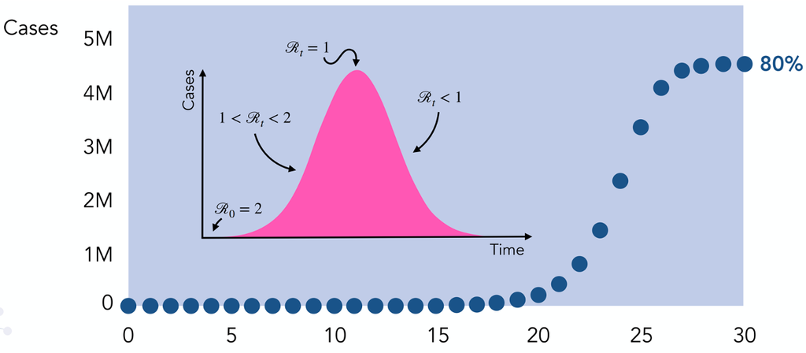

Hệ số lây nhiễm cơ bản và hệ số lây nhiễm hiệu quả

### 3.1 Hệ số lây nhiễm cơ bản ($R_0$)

Hệ số lây nhiễm cơ bản (Reproductive number, $R_0$) là số ca nhiễm trung bình từ một ca nhiễm điển hình ban đầu trong suốt khoảng thời gian lây bệnh của ca nhiễm đó, **trong dân số hoàn toàn cảm nhiễm với bệnh** (tại thời điểm dịch mới xuất hiện).

$R_0$ quan trọng vì:

- $R_0$ giúp xác định khả năng lây lan của bệnh trong cộng đồng. Ví dụ về 1 bệnh nhiễm trùng không tạo miễn dịch suốt đời
  - Khi $R_0$ < 1 bệnh không lây lan
  - Khi $R_0$ gần bằng 1, số ca tăng dần
  - Khi $R_0$ lớn, bệnh lây lan và trở thành bệnh lưu hành
- $R_0$ giúp xác định tốc độ lây truyền của bệnh trong cộng đồng, thông qua ước tính tốc độ tăng trưởng của dịch. $R_0$ càng cao thì dịch có tốc độ tăng trưởng càng nhanh.
- $R_0$ giúp ước tính được quy mô vụ dịch khi kết thúc ($F$). Quy mô này là nghiệm của phương trình

$$F = 1 - exp\{-R_0 \times F\}$$

- $R_0$ giúp ước tính được % số ca bệnh tại đỉnh dịch ($H$). % số ca bệnh này được tính bằng công thức

$$H = 1 - \frac{1}{R_0}$$

- $H$ cũng chính là ngưỡng cân bằng của vụ dịch, và phản ánh mức độ can thiệp cần thiết để kiểm soát vụ dịch. Cần phải ngăn chặn $R_0$ - 1 ca nhiễm mới trong số $R_0$ ca để phòng ngừa lây nhiễm dịch

  $$p_c = \frac{R_0 - 1}{R_0} = 1 - \frac{1}{R_0}$$
  - 50% khi $R_0$ = 2,
  - 75% khi $R_0$ = 4,
  - 90% khi $R_0$ = 10.

    Điều này có thể đạt được bằng cách:
  - Giảm tiếp xúc (cách ly, giãn cách xã hội).
  - Giảm tỉ lệ cảm nhiễm (tiêm phòng, thuốc dự phòng).
  - Giảm khả năng lây nhiễm (ví dụ: điều trị).

Như vậy, chúng ta có thể dùng $R_0$ để

- Đánh giá liệu vụ dịch có đang được kiểm soát hay không.
- Hiểu về mức độ can thiệp cần thiết để kiểm soát hoàn toàn vụ dịch.

### 3.2 Hệ số lây nhiễm hiệu quả ($R_t$)

Hệ số lây nhiễm hiệu quả $R_t$ là số ca nhiễm trung bình từ một ca nhiễm trong quá trình diễn tiến của vụ dịch.

Can thiệp có thể làm thay đổi $R_t$, do đó chỉ số này được dùng để theo dõi và đánh giá hiệu quả của can thiệp.

### 3.3 Cách ước lượng hệ số lây nhiễm

Cần lưu ý rằng, hệ số lây nhiễm không phải là một hằng số sinh học cơ bản!

Về lý thuyết, hệ số lây nhiễm có thể được tính bằng công thức:

$$R = D \times O \times T \times S$$

Trong đó:

- $D$ (Duration) là độ dài của thời kỳ lây nhiễm.
- $O$ (Opportunity) là cơ hội lây nhiễm, thể hiện bằng số lượng tiếp xúc trong một đơn vị thời gian.
- $T$ (Transmission probability) là xác suất lây nhiễm thành công trong một lần tiếp xúc.
- $S$ (Duration) là kích thước của dân số cảm nhiễm, thể hiện bằng % dân số có thể mắc bệnh.

Do đó, hệ số lây nhiễm phụ thuộc vào nhiều yếu tố khác nhau:

- Mầm bệnh sinh học (cơ chế bệnh sinh, vòng đời, tính biến đổi).
- Yếu tố vật chủ (di truyền, dinh dưỡng, tuổi, bệnh đồng mắc).
- Cấu trúc dân số (nhân khẩu học, kiểu mẫu tiếp xúc).

Để ước tính được hệ số lây nhiễm một cách hiệu quả, chúng ta cần sử dụng nhiều loại dữ liệu khác nhau:

- Dữ liệu về sự lây truyền bệnh (transmission): thường không quan sát được, thường dựa vào nghiên cứu đoàn hệ trong hộ gia đình.
- Dữ liệu về kiểu tiếp xúc (contact patterns): thường khó xác định được loại hình tiếp xúc liên quan, dễ dàng nhất là đối với bệnh lây truyền qua quan hệ tình dục, thường thu thập dựa vào điều tra/dữ liệu di chuyển/dữ liệu thu thập qua app điện thoại.
- Dữ liệu về lịch sử tự nhiên của bệnh.
- Dữ liệu về can thiệp: từ nghiên cứu can thiệp hoặc quan sát.

## 4 Mô hình toán học bệnh truyền nhiễm

### 4.1 Mô hình là gì?

Mô hình là sự đơn giản hoá một hệ thống phức tạp, để phù hợp cho việc phân tích. Tất cả mọi người đều dùng mô hình 1 cách vô thức: việc mô tả mô hình bằng toán học làm rõ hơn quá trình tư duy và giúp người khác có thể sử dụng và đánh giá được quá trình đó. Mô hình toán học cho phép thực hiện được các phân tích chính xác, chặt chẽ và dự báo định lượng.

> *Mô hình là công cụ cho sự suy nghĩ*

> *Mọi mô hình đều sai, nhưng một số cũng có ích”*

Khi xây dựng mô hình, cần nắm bắt được những đặc tính cần quan tâm và kết hợp các thuộc tính thiết yếu.

### 4.2 Chúng ta dùng mô hình để làm gì?

[output not shown]

Mô hình có thể được dùng để tổng hợp kiến thức và đơn giản hoá thực tế. Trong thực tế, các mô hình có thể đơn giản hơn thực tế (rất nhiều lần) mà vẫn hữu ích.

Đối với dịch tễ học bệnh truyền nhiễm, mô hình toán học có thể dùng cho 2 nhóm mục tiêu chính:

- Hiểu biết thêm về vai trò và mối quan hệ của các yếu tố khác nhau ảnh hưởng đến sự xuất hiện và diễn tiến của dịch bệnh.
- Dự đoán diễn tiến của dịch bệnh.

Dưới đây là ví dụ về một số câu hỏi có thể giải quyết bằng mô hình:

- Vì sao chúng ta có thể loại trừ bệnh đậu mùa? Chúng ta cần làm thêm điều gì và trong bao lâu nữa để loại trừ bệnh bại liệt?
- Vì sao dịch sởi lặp lại mỗi 2 năm, trong khi norovirus có dịch hàng năm và *S.aureus* lưu hành ổn định?
- Một loại vắc-xin hiệu quả 30% chống lại HIV hoặc sốt rét có thể đạt được tác động gì?
- Chúng ta nên tiêm phòng cho ai để giảm thiểu tác động của dịch cúm mùa trong tương lai – trẻ em, người già hoặc cả hai?
- Chúng ta nên phân bổ nguồn lực như thế nào giữa các biện pháp can thiệp/khu vực địa lý/dân số để đạt được tác động tối đa đối với sức khỏe?

### 4.3 Mô hình bệnh truyền nhiễm

Là dạng mô hình quan tâm đến tác động ở cấp độ dân số của các quá trình xảy ra ở cấp độ cá nhân.

Nguy cơ một người chưa nhiễm bệnh sẽ bị nhiễm bệnh (hay **“lực lây nhiễm”**) phụ thuộc vào:

- Tỉ lệ người nhiễm bệnh trong dân số
- Tần suất (rate) tiếp xúc giữa các cá thể trong dân số
- Khả năng lây truyền của những người đã nhiễm bệnh

Vì vậy sự lây truyền bệnh trong dân số là một quá trình **động** mà nguy cơ nhiễm bệnh có thể thay đổi theo thời gian. Trong đó, số ca mới mắc và số ca hiện mắc phụ thuộc vào nhau theo mối quan hệ phi tuyến tính, với sự tương tác thuận và nghịch thay đổi theo thời gian.

### 4.4 Những điểm cần cân nhắc khi xây dựng mô hình

Về bệnh:

- Diễn tiến tự nhiên của bệnh (ví dụ: thời gian ủ bệnh, thời gian lây nhiễm, khả năng miễn dịch)

Về dân số:

- Sự lây nhiễm (Trực tiếp hay gián tiếp? Điều gì ảnh hưởng tần suất tiếp xúc?)
- Đặc điểm dân số xã hội, cấu trúc dân số (Phân tầng theo tuổi, giới, vị trí địa lý)

Về can thiệp

- Can thiệp (Nhắm đến thành phần nào trong quá trình lây nhiễm bệnh?)

Không có mô hình nào được xem là “đúng nhất” cho một loại bệnh nhất định.

### 4.5 Các bước xây dựng mô hình

1. Thiết kế mô hình
2. Ước lượng tham số
3. Chạy mô hình
4. Diễn giải kết quả

### 4.6 Mô hình khoang (compartment model)

#### Mô hình diễn tiến tự nhiên của bệnh

Chia dân số thành nhiều khoang (phân nhóm)

Mỗi khoang chứa những người ở các trạng thái khác nhau (ví dụ giai đoạn lây nhiễm)

- Người chưa bị nhiễm,
- Người đang nhiễm,
- Người hết khả năng lây nhiễm

Trong mô hình, tất cả những người trong cùng 1 nhóm thì có các đặc tính giống nhau

Được tính bằng cách lấy trung bình các đặc tính trong “thế giới thực”

Mô hình khoang trong bệnh truyền nhiễm được cấu tạo từ 2 thành phần cơ bản:

1. Khoang: chứa những người ở các trạng thái khác nhau (ví dụ giai đoạn lây nhiễm)
- Các giá trị này được chứa trong biến trạng thái, thể hiện trạng thái của hệ thống
2. Tần suất thay đổi số người trong các khoang: ví dụ tỉ suất sinh, số ca nhiễm, tỉ suất hồi phục
- Các giá trị tần suất này thường phụ thuộc vào giá trị của các biến trạng thái, vì vậy khi biến trạng thái thay đổi thì tần suất cũng thay đổi

-> Có sự phản hồi (ví dụ tỉ suất tăng dân số, tỉ suất lây truyền bệnh)

Mối quan hệ giữa các giá trị của biến trạng thái và tần suất thay đổi được thể hiện bằng các hàm số (1 hàm số cho mỗi tần suất thay đổi)

Như vậy, mỗi khoang có:

- 1 biến trạng thái, thể hiện số người đang ở trong khoang này, và
- 1 phương trình vi phân, thể hiện tần suất thay đổi của biến trạng thái, cấu tạo từ 1 hoặc nhiều hàm số

#### Sự di chuyển giữa các khoang

Mỗi giá trị tần suất là **số người đi vào hoặc đi ra khỏi khoang tàu trong 1 đơn vị thời gian**, phụ thuộc vào:

- **Tần suất bình quân đầu người** (nguy cơ); và
- **SỐ người** chịu ảnh hưởng của tần suất này (ví dụ số người phơi nhiễm với nguy cơ)

Tần suất của dân số = Tần suất bình quân đầu người x Số người chịu ảnh hưởng

Tần suất hồi phục sau khi nhiễm bệnh

- Kí hiệu **tần suất hồi phục bình quân đầu người** là $\sigma$
- **SỐ người** bị nhiễm bệnh là $I$

Thì tần suất hồi phục **của dân số** là $\sigma I$

Phân biệt biến trạng thái và tham số của mô hình

Khi phân tích mô hình, chúng ta thay đổi các tham số và xem điều này ảnh hưởng như thế nào đến các biến trạng thái - ví dụ biểu đồ thay đổi như thế nào

| Biến trạng thái (ví dụ $I$) | Tham số (ví dụ $\sigma$) |
| --- | --- |
| Thay đổi sau mỗi vòng lặp khi chạy mô hình | Quy định trước khi chạy mô hình |
| Không thể điều khiển trực tiếp | Thay đổi khi chúng ta muốn |
| Đầu ra của mô hình | Đầu vào của mô hình |

Tần suất chết của nhóm Cảm nhiễm, Hồi phục:

- Cho tần suất chết nền **bình quân đầu người** là $\mu$
- Số người cảm nhiễm là S, số người hồi phục là R
- Tần suất chết của nhóm cảm nhiễm là $\mu S$, của nhóm hồi phục là $\mu R$

Tần suất chết của nhóm Nhiễm bệnh:

- Nhóm nhiễm bệnh vừa có tần suất chết nền ($\mu$) vừa có thể chết do bệnh với tần suất $\alpha$, vậy tần suất chết **bình quân đầu người** là $\mu + \alpha$
- Tần suất chết của nhóm nhiễm bệnh là $(\mu + \alpha) I$

Tỉ suất sinh

- Cho tỉ suất sinh **bình quân đầu người** là $b$
- Giả định rằng tất cả mọi người trong mọi khoang tàu đều có cùng tỉ suất sinh, số người sinh là $S + I + R$, có thể viết gọn bằng cách kí hiệu tổng dân số $N = S + I + R$
- Tỉ suất sinh toàn dân số là $bN$

Khi thực hành, chúng ta thường cho tỉ suất sinh bình quân đầu người bằng với tỉ suất tử bình quân đầu người để giữ dân số không đổi trong trường hợp không có bệnh. Tuy nhiên, không nhất thiết phải luôn làm như vậy nếu chúng ta không muốn

Tần suất nhiễm bệnh

- Tần suất nhiễm bệnh **bình quân đầu người** của nhóm cảm nhiễm (**lực lây nhiễm**) **KHÔNG** giữ cố định (không phải hằng số) mà phụ thuộc vào:
  - Số người nhiễm bệnh trong thời điểm cụ thể, và
  - Tần suất tiếp xúc giữa người cảm nhiễm với người nhiễm bệnh, và
  - Xác suất lây truyền
- Vì vậy, tần suất nhiễm bệnh **của dân số** phụ thuộc vào số người nhiễm bệnh lẫn số người cảm nhiễm trong 1 thời điểm -> phi tuyến tính
- 1 người cảm nhiễm có
  - Tần suất tiếp xúc với 1 người bất kì trong dân số: $c$
  - Tần suất tiếp xúc với 1 người nhiễm bệnh: $cI/N$, với
    - $I$ là số người nhiễm bệnh
    - $N$ là tổng dân số
    - Vậy $I/N$ là tỉ lệ người nhiễm bệnh trong dân số
  - Tần suất bị lây truyền bệnh do tiếp xúc với người nhiễm bệnh: $pcI/N$, với
  - $p$ là xác suất lây truyền bệnh khi 1 người cảm nhiễm tiếp xúc với 1 người nhiễm bệnh
- Số người cảm nhiễm là $S$:
  - Tần suất truyền bệnh của dân số cảm nhiễm là $pcSI/N$
  - Thường kí hiệu $\beta = pc$

Lưu ý: S, I, N là các biến trạng thái sẽ thay đổi theo mỗi vòng chạy mô hình, còn p, c là tham số được quy định từ trước.

### 4.7 Tương lai của mô hình toán học bệnh truyền nhiễm

Trước đây, mô hình toán học bệnh truyền nhiễm thường được ứng dụng nhiều cho các bệnh lưu hành (bệnh lý ở trẻ em, nhiễm ký sinh trùng). Hiện nay, một số hướng tiếp cận đang được quan tâm bao gồm:

- Mô hình động học cho các vụ dịch mới nổi.
- Mô hình theo thời gian thực (real-time modeling).
- Động học theo không gian & thời gian (đối với các bệnh lưu hành).

## 5 Tài liệu tham khảo